# Supporting Information

Diana Buitrago-Garcia, Aziz Mert Ipekci, Leonie Heron, Stefanie Hossmann, Hira Imeri, Georgia Salanti, Nicola Low

10/12/21

## PRISMA 2020 Checklist

*Shiny app can be used to complete checklist here:* https://prisma.shinyapps.io/checklist/

## Search strings

From: Living Evidence on COVID-19 (https://ispmbern.github.io/covid-19/living-review/collectingdata.html, accessed 31.01.2021)

We retrieve data from [EMBASE](http://www.embase.com/) via OVID, [MEDLINE](https://www.ncbi.nlm.nih.gov/pubmed/) via PubMed, BioRxiv and MedRxiv.

**Search terms**

When searches are updated, references that are identified that were not in the database before, are inserted by date (**date_entrez**) they were indexed in remote database, the date they are inserted in OUR database is formatted as the ‘**strategydate**’ (raw data is available [here](https://github.com/leonieheron/LSRworkflow%3E)).

**30.10.2020**

EMBASE:

(exp SARS-related coronavirus/ or severe acute respiratory syndrome/ or coronavirus disease 2019/ or (coronavir* or corona virus* or HCoV* or ncov* or 2019 cov or covid or covid19 or sars-cov* or sarscov* or sars-coronavirus* or Severe Acute Respiratory Syndrome Coronavirus* or nCoV).mp.) and 20191101:20301231.(dc).

MEDLINE:

(“severe acute respiratory syndrome coronavirus 2”[Supplementary Concept] OR “COVID-19” [Supplementary Concept] OR “coronavirus” OR “corona virus” OR “HCoV” OR “nCoV” OR “2019 CoV” OR “covid” OR “covid19” OR “Severe Acute Respiratory Syndrome Coronavirus 2” OR “SARS-CoV2” OR “SARS-CoV 2” OR “SARS Coronavirus 2”) AND (2019/11/01:3000/12/31[PDAT])

EMBASE:

(SARS coronavirus/ or middle east respiratory syndrome/ or severe acute respiratory syndrome/ or (coronavirus* or corona virus* or HCoV* or ncov* or covid or covid19 or sars-cov* or sarscov* or Sars-coronavirus* or Severe Acute Respiratory Syndrome Coronavirus*).mp.) and 20191201:20301231.(dc).

**29.04.2020**

MEDLINE:

(“coronavirus”[MH] OR “coronavirus infections”[MH] OR “coronavirus”[TW] OR “corona virus”[TW] OR “HCoV”[TW] OR “nCov”[TW] OR “covid”[TW] OR “covid19”[TW] OR “Severe Acute Respiratory Syndrome Coronavirus 2”[TW] OR “SARS-CoV2”[TW] OR “SARS-CoV 2”[TW] OR “SARS Coronavirus 2”[TW] OR “MERS- CoV”[TW]) AND (2019/1/1:3000[PDAT])

**01.04.2020**

From 01.04.2020, we retrieve the [BioRxiv/MedRxiv dataset](https://connect.medrxiv.org/relate/content/181).

**26.03.2020**

MEDLINE:

(“Wuhan coronavirus” [Supplementary Concept] OR “COVID-19” OR SARS-CoV-2 OR “2019 ncov”[tiab] OR ((“novel coronavirus”[tiab] OR “new coronavirus”[tiab]) AND (wuhan[tiab] OR 2019[tiab])) OR 2019-nCoV[All Fields] OR (wuhan[tiab] AND coronavirus[tiab]))

EMBASE:

(nCoV or 2019-nCoV or ((new or novel or wuhan) adj3 coronavirus) or covid19 or covid-19 or SARS-CoV-2).mp.

BioRxiv/MedRxiv:

ncov or corona or wuhan or COVID or SARS-CoV-2

With the kind support of the [Public Health & Primary Care Library PHC](https://www.unibe.ch/university/services/university_library/faculty_libraries/medicine/public_health_amp_primary_care_library_phc/index_eng.html), and following guidance of the [Medical Library Association](https://www.mlanet.org/p/cm/ld/fid%3D1713)

**01.01.2020**

MEDLINE:

(“Wuhan coronavirus” [Supplementary Concept] OR “COVID-19” OR “2019 ncov”[tiab] OR ((“novel coronavirus”[tiab] OR “new coronavirus”[tiab]) AND (wuhan[tiab] OR 2019[tiab])) OR 2019-nCoV[All Fields] OR (wuhan[tiab] AND coronavirus[tiab])))))

EMBASE:

ncov OR (wuhan AND corona) OR COVID

BioRxiv/MedRxiv:

ncov or corona or wuhan or COVID

We retained publications that used the keywords listed below in the title or abstract.

“asymp*" OR "pre-symp*” OR “presymp*" OR "preclinical" OR "pre-clinical" OR "without symptoms" OR "no symptoms" OR "free of symptoms" OR "non-symp*” OR "nonsymp*" OR “symptom-free” OR “symptomfree”

## PRISMA 2020 Flowchart

*In progress.* ***

## Risk of bias in studies included in review question 1 and review question 2.

[figure not shown]

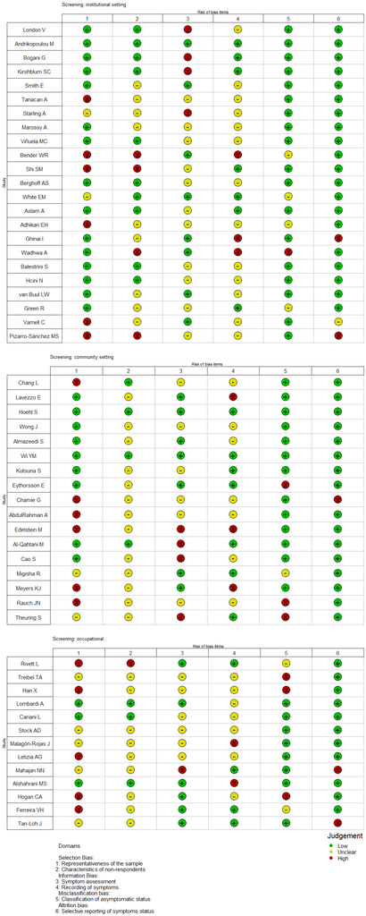

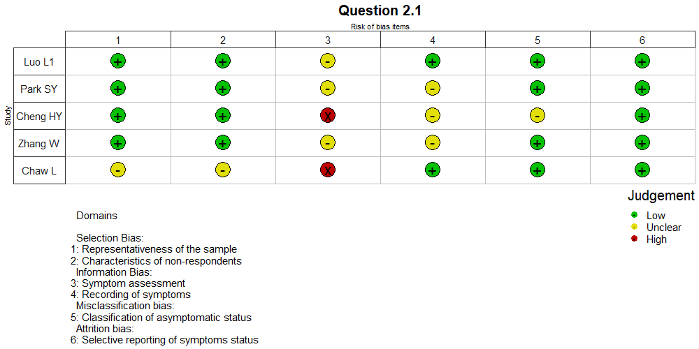

## Review question 1, subgroup analysis comparing studies of hospitalised patients with all other settings.

*Sub-group analysis to be decided*

## Review question 1, sensitivity analysis, omitting studies that were preprints at the time of literature search.

[figure not shown]

Figure 4. Review question 1, sensitivity analysis, omitting studies that were preprints at the time of literature search

## Assessment of credibility of mathematical modelling studies.

*In progress.*

## Types of study included in successive versions of the living systematic review, as of 10 June 2020.

*Settings to be reviewed. Some studies have been reclassified into different settings.*

## Location of studies contributing data to review questions 1 and 2.1.

Table 1. Location of studies contributing data to review questions 1

| Country | Total SARS-CoV-2, n | Total asymptomatic SARS-CoV-2, n | Total number of studies |
| --- | --- | --- | --- |
| United States of America | 9,029 | 3,682 | 28 |
| China | 812 | 422 | 10 |
| United Kingdom | 618 | 289 | 10 |
| Germany | 100 | 9 | 6 |
| Italy | 413 | 88 | 4 |
| South Korea | 928 | 95 | 4 |
| Canada | 53 | 15 | 3 |
| Japan | 150 | 50 | 3 |
| Bahrain | 194 | 119 | 2 |
| Netherlands | 192 | 11 | 2 |
| Spain | 46 | 13 | 2 |
| Austria | 4 | 2 | 1 |
| Belgium | 9 | 4 | 1 |
| Brunei | 138 | 16 | 1 |
| Colombia | 35 | 11 | 1 |
| France | 12 | 1 | 1 |
| French Guyana | 137 | 87 | 1 |
| Greece | 46 | 7 | 1 |
| Iceland | 178 | 25 | 1 |
| India | 467 | 58 | 1 |
| Ireland | 1,105 | 290 | 1 |
| Kuwait | 1,096 | 473 | 1 |
| Malaysia | 46 | 6 | 1 |
| Norway | 40 | 0 | 1 |
| Other | 22 | 4 | 1 |
| Portugal | 14 | 0 | 1 |
| Saudi Arabia | 18 | 12 | 1 |
| Turkey | 3 | 0 | 1 |
| Uganda | 54 | 20 | 1 |
| Vietnam | 208 | 89 | 1 |

*Table 2 in progress.*